# Lecture 05: Sequences

## Arrays

### Arrays

- An array (`numpy.ndarray`) is a sequenced type from the `NumPy` package
- All elements in an array have the same data type
- Math operations work on each element of the array separately
- When adding arrays, elements are added one by one (if they have the same length)
- They're better than lists for handling big datasets efficiently
- We'll frequently use arrays instead of lists in this course
- You can make an array with the `make_array` function from the `datascience` package

### Demo: Arrays

Create an array using `make_array`.

```python
my_array = make_array(1,2,3,4)
my_array
```

```
array([1, 2, 3, 4])
```

```python
type(my_array)
```

```
numpy.ndarray
```

Explore using array arithmetic and notice that the operations create a new array.

```python
my_array*2
```

```
array([2, 4, 6, 8])
```

```python
my_array**2
```

```
array([ 1,  4,  9, 16])
```

```python
my_array+1
```

```
array([2, 3, 4, 5])
```

```python
# my_array is unchanged
my_array
```

```
array([1, 2, 3, 4])
```

Use some functions such as `len` and `sum` on an array

```python
len(my_array)
```

```
4
```

```python
# Built-in sum
sum(my_array)
```

```
10
```

```python
# NumPy sum - optimized for arrays
np.sum(my_array)
```

```
10
```

There are some rules for array arithmetic. For example, you can only add arrays of the same length.

```python
another = make_array(10,20,30,40,50)
```

```python
my_array+another
```

[output not shown]

```python
yet_another = make_array(100, 200, 300)
```

```python
# A ValueError
my_array + yet_another
```

```
---------------------------------------------------------------------------
ValueError                                Traceback (most recent call last)
Cell In[25], line 2
      1 # A ValueError
----> 2 my_array + yet_another

ValueError: operands could not be broadcast together with shapes (4,) (3,)
```

```python
np.sum(another)/len(another)
```

```
30.0
```

You can make an array with non-numeric data types.

```python
tunas_array = make_array('bluefin','albacore','jim')
tunas_array
```

```
array(['bluefin', 'albacore', 'jim'],
      dtype='<U8')
```

## Indexing Sequences

### Indexes

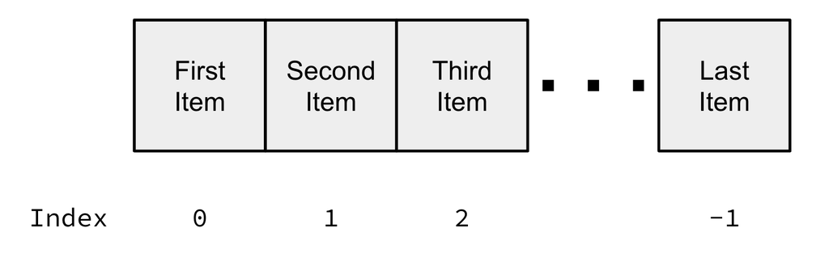

Sequence data types have a variety of ways to access each item in the sequence:

- A standard way: Use the item's position number in the sequence (index) with bracket `[...]` notation
  - Indices start with `0`
- Array way specific in MATH 108: NumPy arrays in our class can be indexed with the `.item()` method

### Demo: Indexing

Get the first character from a string.

```python
another_string = "San Francisco"
another_string
```

```
'San Francisco'
```

```python
another_string[0]
```

```
'S'
```

Get the last character from a string.

```python
len(another_string)
```

```
13
```

```python
# An IndexError
another_string[13]
```

```
---------------------------------------------------------------------------
IndexError                                Traceback (most recent call last)
Cell In[33], line 2
      1 # An IndexError
----> 2 another_string[13]

IndexError: string index out of range
```

```python
another_string[12]
```

```
'o'
```

```python
# Another way to access the last item in a sequence.
another_string[-1]
```

```
'o'
```

```python
# And another way ...
num_items = len(another_string)
another_string[num_items-1]
```

```
'o'
```

Access items in an array using .item and bracket notation.

```python
an_array = make_array('eats', 'shoots', 'leaves')
an_array
```

```
array(['eats', 'shoots', 'leaves'],
      dtype='<U6')
```

```python
an_array[0]
```

```
'eats'
```

```python
an_array.item(0)
```

```
'eats'
```

```python
an_array[-1]
```

```
'leaves'
```

```python
an_array.item(-1)
```

```
'leaves'
```

Be careful! Check your data types because sometimes you don't get what you expect.

```python
another_array = make_array(10, 20, 30)
another_array
```

```
array([10, 20, 30])
```

```python
type(another_array[0])
```

```
numpy.int64
```

```python
type(another_array.item(0))
```

```
int
```

## NumPy

### NumPy Functions

- NumPy is a Python library with a collection of tools optimized to work with arrays
- In our reference material, array tools commonly start with `np`
- One function `np.arange` is really helpful for generating arrays of numbers
  - General command: `np.arange(start, stop, step)`
  - the `start` and `step` values have a default of 0 and 1, respectively
  - `np.arange(5)` creates the array `array([0, 1, 2, 3, 4])`
  - `np.arange(1, 5)` creates the array `array([1, 2, 3, 4])`
  - `np.arange(1, 5, 2)` creates the array `array([1, 3])`
  - `np.arange` is not the same as `range`

### Demo: NumPy Functions

Generate arrays with `arange`.

```python
np.arange(0,200,30)
```

```
array([  0,  30,  60,  90, 120, 150, 180])
```

```python
type(np.arange(200))
```

```
numpy.ndarray
```

```python
my_array = np.arange(0,200,30)
my_array
```

```
array([  0,  30,  60,  90, 120, 150, 180])
```

Demonstrate a few NumPy functions, attributes, and methods.

```python
np.average(my_array)
```

```
90.0
```

```python
np.diff(my_array)
```

```
array([30, 30, 30, 30, 30, 30])
```

```python
np.cumsum(my_array)
```

```
array([  0,  30,  90, 180, 300, 450, 630])
```

```python
# an array attribute
my_array.size
```

```
7
```

```python
# an array method
my_array.min()
```

```
0
```

## Attribution

This content is licensed under the Creative Commons Attribution-NonCommercial-ShareAlike 4.0 International License (CC BY-NC-SA 4.0) and derived from the Data 8: The Foundations of Data Science offered by the University of California, Berkeley.